# Decision Trees and Random Forests on Forest Fires

Used the resources provided, things that I learned previously, and [this website](https://towardsdatascience.com/random-forest-hyperparameters-and-how-to-fine-tune-them-17aee785ee0d#:~:text=The%20most%20important%20hyper%2Dparameters,MSE%20or%20MAE%20for%20regression)

## Start

### Loading Libraries and Data

```r
# load packages
library(tidyverse) #for ggplot and dplyr
library(corrplot) #for correlation plots
# decision tree packages
library(rpart)
library(caTools)
library(rpart.plot)
library(RColorBrewer)
library(rattle)
# random forest package
library(randomForest)
```

```r
setwd("C:/Users/ezhou/OneDrive - Eastside Preparatory School/Documents/Eric/2022 - 2023/1 Fall/A Data Science/Forest Fires")
forestRaw <- read.csv("forestfires.csv")
```

### Data Preprocessing

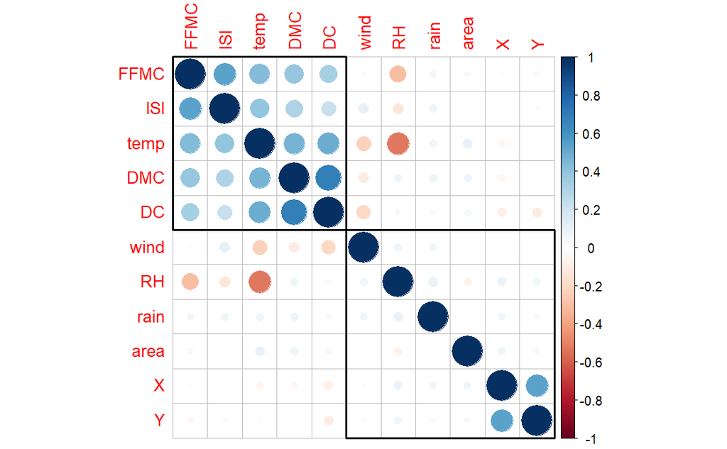

```r
# summary(forestRaw)

forestNum <- forestRaw %>% select(-month, -day)
corrs <- cor(forestNum)
corrplot(corrs, order = 'hclust', addrect = 2)
```

```r
# RMSE function
myRMSE <- function(pred, obs) {
  return(sqrt(mean((pred - obs) ^ 2, na.rm = TRUE)))
}
```

```r
forestNum <- forestNum %>% mutate(logArea = log(area+1))
# summary(forestNum)
```

## Decision Tree

Decision trees are flow-chart-like structures that are used to make decisions. Each node in the tree is like an if-statement, where those fulfilling the condition go down on branch and those that don’t go down another. This keeps going until a leaf node, which is the final value/categorization you arrive at. So basically, based on the value of a variety of features that are evaluated in an order, you get a value/categorization. I believe the primary parameter to tune is the complexity parameter (cp), which determines how much of the tree to prune.

### Splitting Data

```r
set.seed(49301)
ind <- sample.split(Y=forestNum, SplitRatio=0.8)
trainData <- forestNum[ind,]
testData <- forestNum[-ind,]
```

### Creating Tree

```r
start1 <- Sys.time() # starting time
output.tree <- rpart(logArea ~.-area,data=trainData, method='anova')
end1 <- Sys.time() # Finishing time
(time1 <- end1 - start1) # total time
```

```
Time difference of 0.0302012 secs
```

### Visualizing the Tree

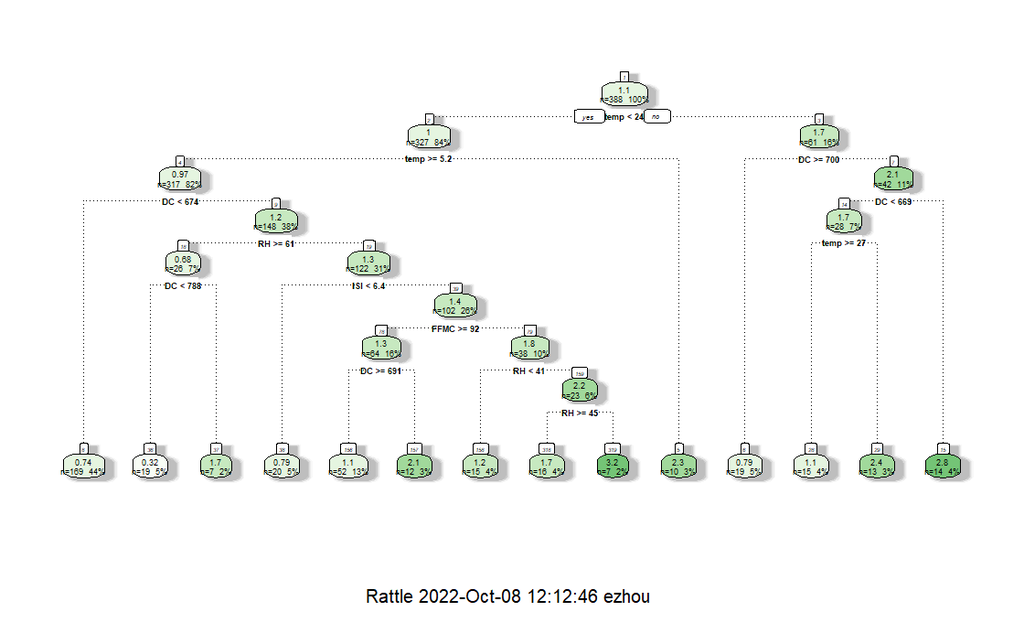

```r
# plot(output.tree)
# text(output.tree, pretty=0)
# summary(output.tree)
fancyRpartPlot(output.tree)
```